# Yifan_Wu_HW8

Yifan Wu

April 6, 2018

# 8.4.1. Draw an example (of your own invention) of a partition of twodimensional feature space that could result from recursive binary splitting. Your example should contain at least six regions. Draw a decision tree corresponding to this partition. Be sure to label all aspects of your figures, including the regions R1,R2, . . ., the cutpoints t1, t2, . . ., and so forth.

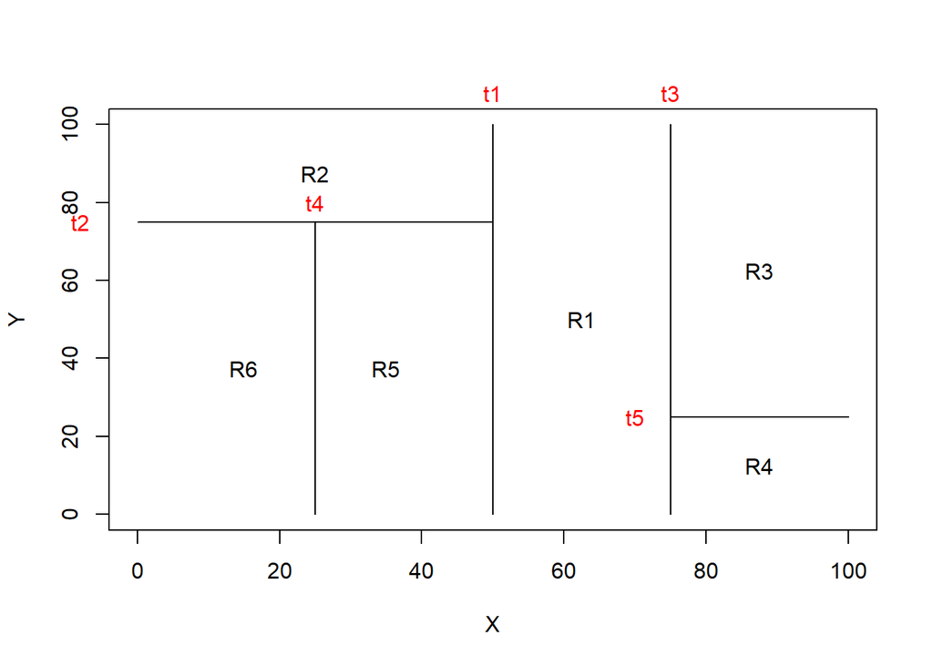

```r
par(xpd = NA)
plot(NA, NA, type = "n", xlim = c(0,100), ylim = c(0,100), xlab = "X", ylab = "Y")
lines(x = c(50,50), y = c(0,100))
text(x = 50, y = 108, labels = c("t1"), col = "red")
lines(x = c(0,50), y = c(75,75))
text(x = -8, y = 75, labels = c("t2"), col = "red")
lines(x = c(75,75), y = c(0,100))
text(x = 75, y = 108, labels = c("t3"), col = "red")
lines(x = c(25,25), y = c(0,75))
text(x = 25, y = 80, labels = c("t4"), col = "red")
lines(x = c(75,100), y = c(25,25))
text(x = 70, y = 25, labels = c("t5"), col = "red")

text(x = (50+75)/2, y = 50, labels = c("R1"))
text(x = 25, y = (100+75)/2, labels = c("R2"))
text(x = (75+100)/2, y = (100+25)/2, labels = c("R3"))
text(x = (75+100)/2, y = 25/2, labels = c("R4"))
text(x = 35, y = 75/2, labels = c("R5"))
text(x = 15, y = 75/2, labels = c("R6"))
```

# 8.4.4.This question relates to the plots in Figure 8.12.

## (a). Sketch the tree corresponding to the partition of the predictor space illustrated in the left-hand panel of Figure 8.12. The numbers inside the boxes indicate the mean of Y within each region.

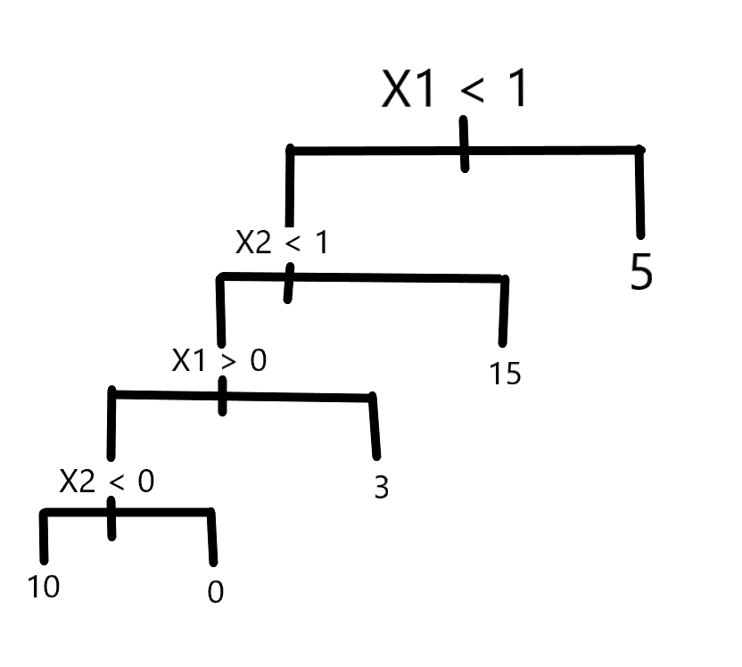

“Tree graph of the block graph in Figure 8.12 left”

## (b).Create a diagram similar to the left-hand panel of Figure 8.12, using the tree illustrated in the right-hand panel of the same figure. You should divide up the predictor space into the correct regions, and indicate the mean for each region.

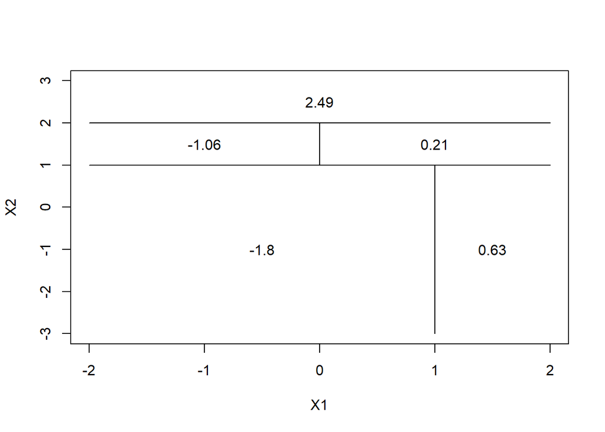

```r
par(xpd = NA)
plot(NA, NA, type = "n", xlim = c(-2, 2), ylim = c(-3, 3), xlab = "X1", ylab = "X2")
lines(x = c(-2, 2), y = c(1, 1))
lines(x = c(1, 1), y = c(-3, 1))
text(x = (-2 + 1)/2, y = -1, labels = c(-1.8))
text(x = 1.5, y = -1, labels = c(0.63))
lines(x = c(-2, 2), y = c(2, 2))
text(x = 0, y = 2.5, labels = c(2.49))
lines(x = c(0, 0), y = c(1, 2))
text(x = -1, y = 1.5, labels = c(-1.06))
text(x = 1, y = 1.5, labels = c(0.21))
```

# 8.4.9. (omit c)

## (a).Create a training set containing a random sample of 800 observations, and a test set containing the remaining observations.

```r
library(ISLR)
set.seed(1)
train <- sample(1:nrow(OJ), 800)
OJ.train <- OJ[train, ]
OJ.test <- OJ[-train, ]
```

## (b).Fit a tree to the training data, with Purchase as the response and the other variables as predictors. Use the summary() function to produce summary statistics about the tree, and describe the results obtained. What is the training error rate? How many terminal nodes does the tree have?

```r
library(tree)
tree.oj <- tree(Purchase ~ ., data = OJ.train)
summary(tree.oj)
```

```
##
## Classification tree:
## tree(formula = Purchase ~ ., data = OJ.train)
## Variables actually used in tree construction:
## [1] "LoyalCH"       "PriceDiff"     "SpecialCH"     "ListPriceDiff"
## Number of terminal nodes:  8
## Residual mean deviance:  0.7305 = 578.6 / 792
## Misclassification error rate: 0.165 = 132 / 800
```

The fitted tree has a training error rate of 0.165 and 8 terminal nodes.

## (d).Create a plot of the tree, and interpret the results.

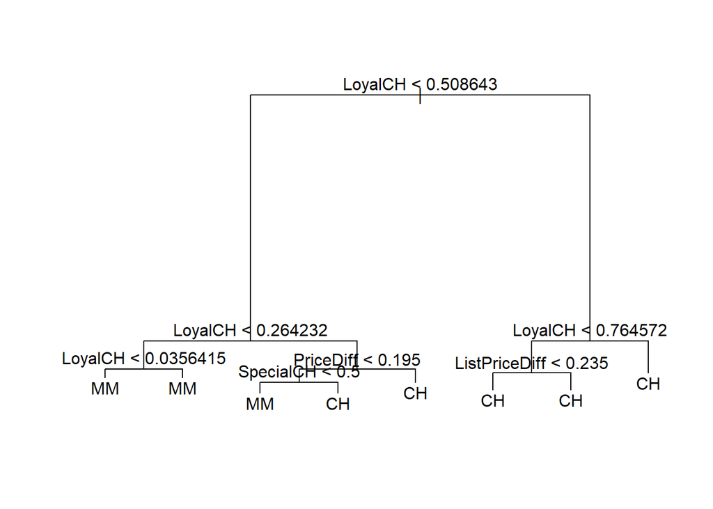

```r
plot(tree.oj)
text(tree.oj, pretty = 0)
```

we can see that the predictor that could potentially influence the Purchase the most is LoyalCH because the top two layers of the tree contain LoyalCH.

## (e).Predict the response on the test data, and produce a confusion matrix comparing the test labels to the predicted test labels. What is the test error rate?

```r
tree.pred <- predict(tree.oj, OJ.test, type = "class")
table(tree.pred, OJ.test$Purchase)
```

```
##
## tree.pred  CH  MM
##        CH 147  49
##        MM  12  62
```

The error rate:

```r
unpruned_test_error = 1 - (147 + 62) / 270
unpruned_test_error
```

```
## [1] 0.2259259
```

The error rate is about 0.226.

## (f).Apply the cv.tree() function to the training set in order to determine the optimal tree size.

```r
cv.oj <- cv.tree(tree.oj, FUN = prune.misclass)
cv.oj
```

```
## $size
## [1] 8 5 2 1
##
## $dev
## [1] 156 156 156 306
##
## $k
## [1]       -Inf   0.000000   4.666667 160.000000
##
## $method
## [1] "misclass"
##
## attr(,"class")
## [1] "prune"         "tree.sequence"
```

## (g).Produce a plot with tree size on the x-axis and cross-validated classification error rate on the y-axis.

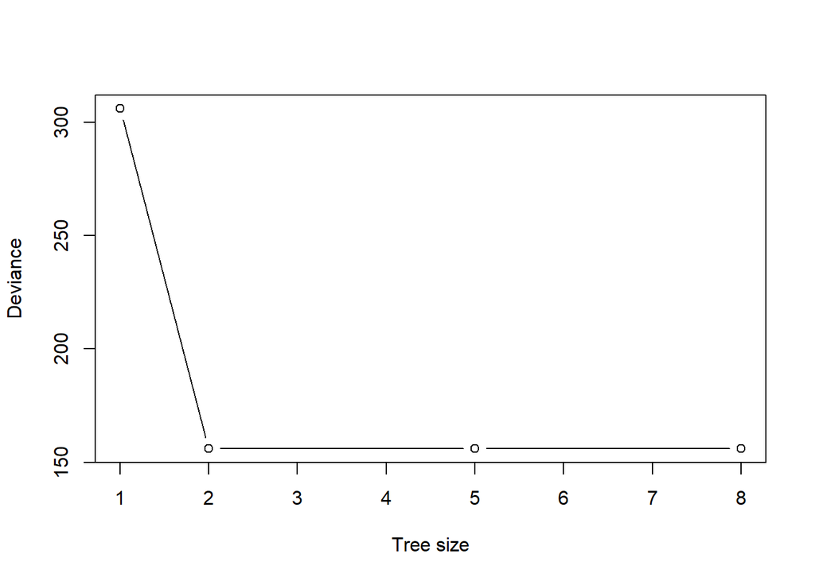

```r
plot(cv.oj$size, cv.oj$dev, type = "b", xlab = "Tree size", ylab = "Deviance")
```

## (h).Which tree size corresponds to the lowest cross-validated classification error rate?

From the plot we can see that the 2-node tree is the smallest tree with the lowest classification error rate.

## (i).Produce a pruned tree corresponding to the optimal tree size obtained using cross-validation. If cross-validation does not lead to selection of a pruned tree, then create a pruned tree with five terminal nodes.

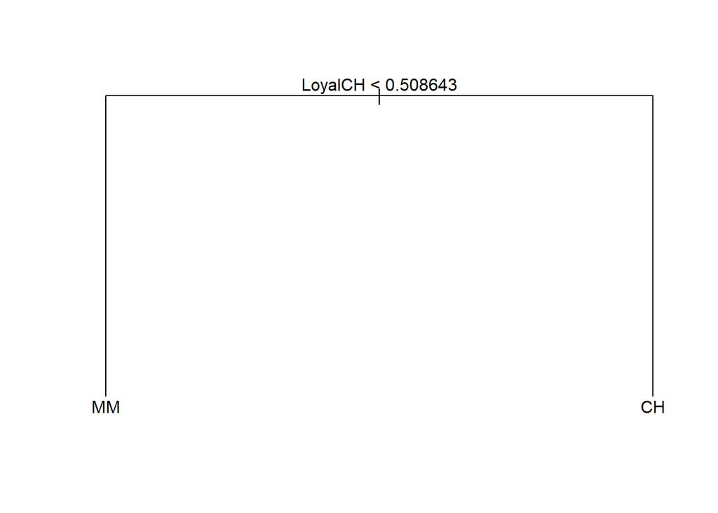

```r
prune.oj <- prune.misclass(tree.oj, best = 2)
plot(prune.oj)
text(prune.oj, pretty = 0)
```

## (j).Compare the training error rates between the pruned and unpruned trees. Which is higher?

```r
summary(tree.oj)
```

```
##
## Classification tree:
## tree(formula = Purchase ~ ., data = OJ.train)
## Variables actually used in tree construction:
## [1] "LoyalCH"       "PriceDiff"     "SpecialCH"     "ListPriceDiff"
## Number of terminal nodes:  8
## Residual mean deviance:  0.7305 = 578.6 / 792
## Misclassification error rate: 0.165 = 132 / 800
```

```r
summary(prune.oj)
```

```
##
## Classification tree:
## snip.tree(tree = tree.oj, nodes = c(3L, 2L))
## Variables actually used in tree construction:
## [1] "LoyalCH"
## Number of terminal nodes:  2
## Residual mean deviance:  0.9115 = 727.4 / 798
## Misclassification error rate: 0.1825 = 146 / 800
```

The misclassification error rate is slightly higher for the pruned tree.

## (k).Compare the test error rates between the pruned and unpruned trees. Which is higher?

```r
pruned.pred <- predict(prune.oj, OJ.test, type = "class")
table(pruned.pred, OJ.test$Purchase)
```

```
##
## pruned.pred  CH  MM
##          CH 119  30
##          MM  40  81
```

```r
pruned_test_error = 1 - (119 + 81) / (119 + 81 + 40 + 30)
pruned_test_error
```

```
## [1] 0.2592593
```

```r
unpruned_test_error
```

```
## [1] 0.2259259
```

In this case, the prund tree have a higher test error rate; 26%. But the pruned tree is far more easier to interpret than the unpruned tree.

# 8.4.12. Apply boosting, bagging, and random forests to a data set of your choice. Be sure to fit the models on a training set and to evaluate their performance on a test set. How accurate are the results compared to simple methods like linear or logistic regression? Which of these approaches yields the best performance? Do this with the MNIST_6-8 data we’ve used previously [8 pts] - use only 2 out of the three Ensemble methods, your choice - no need to use all 784 features, pick a few dozen.

```r
load("mnist68.RData")

dim(mnist68)
```

```
## [1] 11769   785
```

```r
table(mnist68$labels)
```

```
##
##    6    8
## 5918 5851
```

Data slicing:

We choose 90 pixels that has the largest variance for model training.

```r
library(plyr)
var.68 = colwise(var)(mnist68)
var.68.sort = sort(var.68, decreasing = TRUE)
partial_68_cols = colnames(var.68.sort)[1:90]
partial_68 = mnist68[c(partial_68_cols, "labels")]
```

```r
dim(partial_68)
```

```
## [1] 11769    91
```

```r
table(partial_68$labels)
```

```
##
##    6    8
## 5918 5851
```

Setting training set and testing set:

```r
set.seed(11)
sample.train = sample(1:dim(partial_68)[1], dim(partial_68)[1] / 2) #Sample all rows, only keep half of them
sample.test = - sample.train

#training set for logistic regression, need labels to be integer(0 or 1).
train68.logistic <-  partial_68[sample.train, ]
test68.logistic <- partial_68[sample.test, ]

#training set for bagging and rf regression, need labels to be factors.
partial_68$labels <- as.factor(partial_68$labels)
train68 <- partial_68[sample.train, ]
test68 <- partial_68[sample.test, ]
```

```r
train68.logistic$labels[train68$labels == 6] <- 0
train68.logistic$labels[train68$labels == 8] <- 1


logistic.model.68 <- glm(labels ~., data = train68.logistic, family = binomial)
summary(logistic.model.68)
```

```
##
## Call:
## glm(formula = labels ~ ., family = binomial, data = train68.logistic)
##
## Deviance Residuals:
##     Min       1Q   Median       3Q      Max
## -3.6751  -0.0454  -0.0021   0.0232   3.2939
##
## Coefficients:
##               Estimate Std. Error z value Pr(>|z|)
## (Intercept) -8.017e-01  3.709e-01  -2.161 0.030670 *
## V186        -1.952e-03  2.567e-03  -0.761 0.446926
## V658        -2.158e-03  3.318e-03  -0.650 0.515458
## V657         8.449e-03  3.264e-03   2.589 0.009632 **
## V546         2.810e-03  2.455e-03   1.144 0.252427
## V458        -8.640e-04  2.928e-03  -0.295 0.767940
## V547         4.172e-04  2.552e-03   0.163 0.870162
## V486        -3.196e-04  2.894e-03  -0.110 0.912072
## V523        -7.798e-04  2.686e-03  -0.290 0.771554
## V379         2.419e-03  2.107e-03   1.148 0.250859
## V631         1.030e-03  2.829e-03   0.364 0.715868
## V574         1.629e-03  2.243e-03   0.726 0.467546
## V430        -7.276e-03  3.016e-03  -2.413 0.015839 *
## V185         1.226e-03  2.261e-03   0.542 0.587786
## V213         4.035e-03  2.291e-03   1.761 0.078244 .
## V629        -4.429e-03  2.656e-03  -1.668 0.095413 .
## V375        -9.156e-03  2.693e-03  -3.399 0.000675 ***
## V630        -2.997e-03  2.792e-03  -1.073 0.283108
## V403         6.591e-03  2.778e-03   2.373 0.017668 *
## V551        -1.594e-03  2.660e-03  -0.599 0.548974
## V378         2.799e-03  2.023e-03   1.384 0.166482
## V355        -5.967e-04  2.237e-03  -0.267 0.789670
## V187         2.875e-03  1.780e-03   1.615 0.106295
## V431        -3.853e-04  2.654e-03  -0.145 0.884558
## V524        -2.099e-03  2.025e-03  -1.037 0.299967
## V212         4.035e-04  2.282e-03   0.177 0.859664
## V548        -6.598e-04  2.488e-03  -0.265 0.790871
## V354        -5.907e-03  2.511e-03  -2.352 0.018665 *
## V236        -2.790e-03  3.182e-03  -0.877 0.380520
## V519        -6.789e-03  2.605e-03  -2.606 0.009150 **
```

[output cut: 56 more lines]

```
## V211        -2.508e-03  2.024e-03  -1.239 0.215315
## V579        -3.156e-03  1.957e-03  -1.612 0.106887
## V380         3.026e-03  1.799e-03   1.682 0.092595 .
## V235         9.487e-03  2.705e-03   3.507 0.000453 ***
## V318         2.895e-03  2.503e-03   1.156 0.247515
## ---
## Signif. codes:  0 '***' 0.001 '**' 0.01 '*' 0.05 '.' 0.1 ' ' 1
##
## (Dispersion parameter for binomial family taken to be 1)
##
##     Null deviance: 8155.32  on 5883  degrees of freedom
## Residual deviance:  861.22  on 5793  degrees of freedom
## AIC: 1043.2
##
## Number of Fisher Scoring iterations: 9
```

```r
prob.logistic <- predict(logistic.model.68, test68.logistic, type='response')
logistic.pred68 = rep(6, length(test68.logistic$labels))
logistic.pred68[prob.logistic >.5] = 8
table(logistic.pred68, test68.logistic$labels)
```

```
##
## logistic.pred68    6    8
##               6 2854  108
##               8   73 2850
```

Test error:

```r
(73 + 108) / (2854 + 2850 + 73 + 108)
```

```
## [1] 0.03075616
```

So the test error using logistic regression for classifying 6 and 8 is about 3.1%.

Bagging:

We choose all of the predictors in the dataset to perform bagging.

```r
partial_68$labels <- as.factor(partial_68$labels)



library(randomForest)
set.seed (1)
bag.partial68 = randomForest(labels ~., data = train68, mtry=90, importance =TRUE)
bag.partial68
```

```
##
## Call:
##  randomForest(formula = labels ~ ., data = train68, mtry = 90,      importance = TRUE)
##                Type of random forest: classification
##                      Number of trees: 500
## No. of variables tried at each split: 90
##
##         OOB estimate of  error rate: 2.82%
## Confusion matrix:
##      6    8 class.error
## 6 2916   75  0.02507523
## 8   91 2802  0.03145524
```

```r
bag.pred = predict(bag.partial68, newdata = test68, type = "class")
table(bag.pred, test68$labels)
```

```
##
## bag.pred    6    8
##        6 2870   84
##        8   57 2874
```

```r
bag.test.error = (84 + 57) / (2870 + 2874 + 84 + 57)
bag.test.error
```

```
## [1] 0.02395922
```

The test classification error rate when using bagging is about 2.4%.

Random Forest:

Choose $\sqrt p = \sqrt 90 \approx 10$ predictors to perform random forest classification.

```r
set.seed(1)
rf.partial68 = randomForest(labels ~., data = train68, mtry = 10, importance =TRUE)
rf.partial68
```

```
##
## Call:
##  randomForest(formula = labels ~ ., data = train68, mtry = 10,      importance = TRUE)
##                Type of random forest: classification
##                      Number of trees: 500
## No. of variables tried at each split: 10
##
##         OOB estimate of  error rate: 2.58%
## Confusion matrix:
##      6    8 class.error
## 6 2908   83  0.02774992
## 8   69 2824  0.02385067
```

```r
rf.pred = predict(rf.partial68, newdata = test68, type = "class")
table(rf.pred, test68$labels)
```

```
##
## rf.pred    6    8
##       6 2872   65
##       8   55 2893
```

```r
rf.test.error = (65 + 55) / (2872 + 2893 + 65 + 55)
rf.test.error
```

```
## [1] 0.02039082
```

The test classification error rate when using random forest is about 2.0%.